# Flexible Damage Functions

Author

James Rising, Sebastian Cadavid Sanchez, Climate Impact Lab

Published

April 30, 2026

## 0.1 Agriculture: Wheat Spring Country

Flexible damage function parameters at the Country level.

**Change in spring wheat yields (log change in yields) under full adaptation**

**Outcome units:** `physical` — log change in wheat spring yield (population-weighted to country)

$$D_{it} = (\alpha_i T_t + \beta_i T_t^2) \cdot Y_{it}^{\gamma}$$

where $\gamma$ is the income elasticity (fitted globally), $\alpha_i$ is the linear coefficient, and $\beta_i$ is the quadratic coefficient.

# 1 Global Estimation

## 1.1 Income Elasticity Estimation

The income elasticity $\gamma$ is estimated using a fixed-effects regression:

$$y_{it} = \gamma \cdot \log(Y_{it}) + \mu_{g(i,T)} + \nu_t + \varepsilon_{it}$$

where $\mu_{g(i,T)}$ are region-by-temperature-bin fixed effects and $\nu_t$ are year fixed effects.

Table 1: Income Elasticity (Gamma) Estimation Results

| Statistic | Value |
| --- | --- |
| Income elasticity ($\gamma$) | -0.0097 |
| Standard error | 3.70e-03 |
| 95% CI | [-0.0170, -0.0024] |
| R-squared | 0.2949 |
| Observations | 1,913,535 |
| Regions | 138 |
| Gamma quantiles | 19 |

# 2 Parameter Distributions

## 2.1 8-Panel Summary

Row 1: gamma, alpha, beta, rsqr1. Row 2: rho, zeta, eta, rsqr2.

```
Using median gamma: -0.009695, 138 rows (of 2,622 total)
```

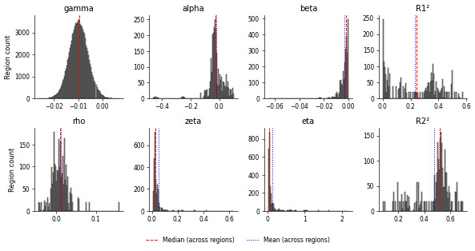

Figure 1: Distribution of Regional Parameters

## 2.2 Projection Equation and Parameter Definitions

The estimated parameters are used to project damages via Monte Carlo sampling:

$$D_{it}^k = (\hat{\alpha}_{ik} T_t + \hat{\beta}_{ik} T_t^2) Y_{it}^{\hat{\gamma}_k} + \hat{\theta}_{ik} T_t Y_{it}^{\hat{\gamma}_k} + \hat{\phi}_{it}^k$$

where $k$ indexes the Monte Carlo draw. The parameters in each row of the output CSV control distinct components of this equation:

- **gamma**: income elasticity $\hat{\gamma}_k$, one of 19 quantile values drawn from $N(\hat{\gamma}, SE(\hat{\gamma}))$
- **alpha, beta**: linear and quadratic temperature coefficients; $\hat{\alpha}_{ik}$ and $\hat{\beta}_{ik}$ are drawn from the joint normal defined by the VCV below
- **sigma11, sigma12, sigma22**: variance-covariance matrix of $(\alpha, \beta)$, used for joint uncertainty sampling
- **rho**: correlation between regional and global polynomial residuals $\rho_i$, used to maintain spatial covariance across regions in Monte Carlo draws
- **zeta**: temperature-dependent error scale $\zeta_{ik}$; the run-specific error term $\hat{\theta}_{ik}$ is drawn from $N(0, \zeta_{ik})$
- **eta**: residual noise standard deviation $\eta_{ik}$; the annual noise $\hat{\phi}_{it}^k$ is drawn from $N(0, \eta_{ik})$
- **rsqr1, rsqr2**: polynomial fit quality and error model fit, respectively

## 2.3 Summary Statistics

Table 2: Regional Parameter Summary

| Parameter | Mean | Median | Std | Min | Max | N |
| --- | --- | --- | --- | --- | --- | --- |
| alpha | -0.0226 | -0.02885 | 0.05976 | -0.4412 | 0.09642 | 138 |
| beta | -0.003589 | -0.002258 | 0.005925 | -0.06068 | 0 | 138 |
| rho | 0.01059 | 0.008731 | 0.0237 | -0.04477 | 0.1582 | 138 |
| zeta | 0.04907 | 0.02724 | 0.07905 | 0.01027 | 0.5967 | 138 |
| eta | 0.1394 | 0.05308 | 0.2848 | 0.01929 | 2.046 | 138 |
| rsqr1 | 0.2287 | 0.243 | 0.1765 | 7.385e-06 | 0.5772 | 138 |
| rsqr2 | 0.4732 | 0.5174 | 0.1372 | 0.0797 | 0.7003 | 138 |

# 3 Spaghetti Curves

Regional damage function curves showing D(T) = αT + βT² for sampled regions.

[interactive chart not shown]

Figure 2: Regional Damage Functions

# 4 Zero Crossings

The zero crossing (extremum) of the parabola occurs at $T^* = -\alpha / (2\beta)$.

Table 3: Zero Crossing Statistics

| Category | Count | Percentage |
| --- | --- | --- |
| β = 0 (no crossing) | 18 | 13.0% |
| T > 20°C (beyond graph) | 0 | 0.0% |
| T < 0°C (negative crossing) | 84 | 60.9% |
| Valid crossings (0-20°C) | 36 | 26.1% |

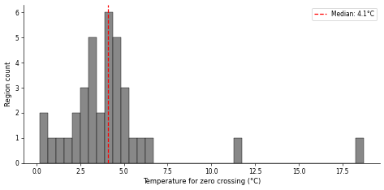

Figure 3: Distribution of Zero Crossing Temperatures

# 5 Slope Analysis

Maximum slope between 0 and 10°C: $\frac{dM}{dT} = \alpha + 2\beta T$

The maximum occurs at either T=0 or T=10 (endpoints of interval).

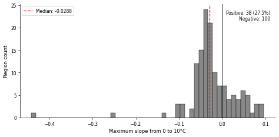

Figure 4: Distribution of Maximum Slopes (0-10°C)

*Convexity analysis omitted (beta constraint active).*

# 6 R-squared Analysis

## 6.1 Polynomial Fit Quality (rsqr1)

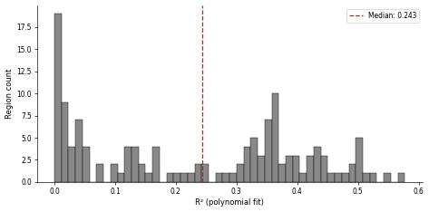

Figure 5: Regional Fit Quality (R-squared)

## 6.2 Error Model R-squared (rsqr2) Quantiles

Table 4: rsqr2 Quantiles

| 0% (Min) | 25% | 50% (Median) | 75% | 100% (Max) |
| --- | --- | --- | --- | --- |
| 0.0797 | 0.4012 | 0.5174 | 0.5582 | 0.7003 |

# 7 Modelled Variance

Modelled variance statistic: $1 - \frac{\sum_i \eta_i^2}{\sum_i D_i^2}$

Table 5: Modelled Variance Statistics

| Statistic | Value |
| --- | --- |
| Modelled variance | -1.2434 |
| Sum(η²) | 13.7972 |
| Sum(D²) at T=3.0°C | 6.1503 |
| N regions | 138 |

# 8 Best- and Worst-Fitting Regions

The 3 worst- and 3 best-fitting regions by R-squared, with raw simulation data overlaid on the fitted polynomial curve. **Red rows = worst fits**, **green rows = best fits**.

Table 6: Best- and worst-fitting regions

Top 3 best fit (R²) Top 3 worst fit (R²)

[output not shown]

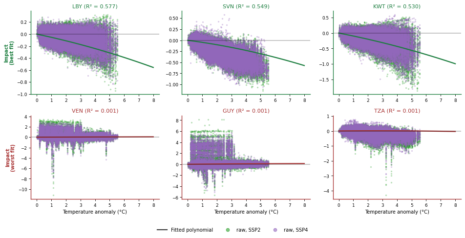

# 9 Regional Parameter Maps

Maps of key parameters at the **country** level. Red = negative (damage increases with T), Blue = positive.

## 9.1 Alpha (Linear Coefficient)

Alpha ($\alpha$) represents the linear sensitivity to temperature. Regions with negative alpha experience damage that increases with the first degree of warming.

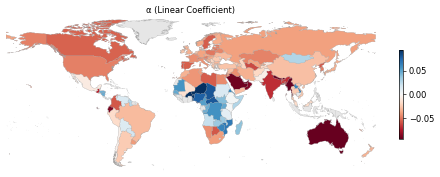

Figure 7: α (linear coefficient)

## 9.2 Beta (Quadratic Coefficient)

Beta ($\beta$) represents the curvature of the damage function.

The concavity ($\beta \leq 0$) constraint is enforced for this sector, meaning optimal temperature exists, damages accelerate beyond it.

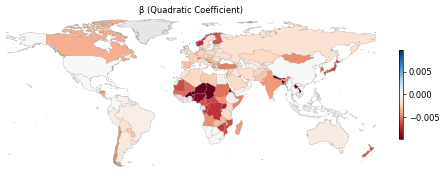

Figure 8: β (quadratic coefficient)

## 9.3 R-squared (Fit Quality)

$R^2$ measures the polynomial fit quality. Higher values indicate that the quadratic form captures more of the variance in the data.

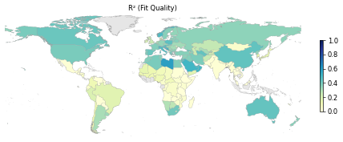

Figure 9: R² (stage 1 fit quality)

# 10 F2: Flex vs Raw Comparison

Comparison of flexible damage function predictions against raw simulation means.

For each scenario (RCP × SSP × Model), we compute at the final year:

- **Flex predicted**: $(\alpha \cdot T + \beta \cdot T^2) \cdot Y^\gamma$
- **Raw actual**: The outcome variable (y) from the source data

**Year 2098**: 971,520 rows

**rcp45**

**SSP2**

**high**

**Correlation:** 0.7150 | **RMSE:** 0.165651 | **Sign agreement:** 77.5%

[interactive chart not shown]

Top 5 best predicted Top 5 worst predicted

Year 2098 · T<sub>mean</sub> across these regions: 1.94°C

| Region | Raw | Flex | Residual |
| --- | --- | --- | --- |
| GRC | -0.0604 | -0.0593 | 0.00116 |
| ESP | -0.104 | -0.107 | -0.00354 |
| PRT | -0.0981 | -0.104 | -0.00548 |
| CA- | -0.028 | -0.0352 | -0.0072 |
| TUN | -0.0632 | -0.0725 | -0.0093 |
| BTN | -1.44 | -0.816 | 0.621 |
| BGD | -0.783 | -0.316 | 0.467 |
| VNM | -0.438 | -0.0449 | 0.393 |
| SWZ | -0.336 | 0.0163 | 0.353 |
| IND | -0.467 | -0.135 | 0.331 |

**low**

**Correlation:** 0.7369 | **RMSE:** 0.148420 | **Sign agreement:** 79.0%

[interactive chart not shown]

Top 5 best predicted Top 5 worst predicted

Year 2098 · T<sub>mean</sub> across these regions: 1.94°C

| Region | Raw | Flex | Residual |
| --- | --- | --- | --- |
| IRQ | -0.0808 | -0.0793 | 0.00153 |
| GRC | -0.0616 | -0.0591 | 0.00247 |
| KGZ | -0.0147 | -0.0173 | -0.00263 |
| MAR | -0.0562 | -0.0617 | -0.00552 |
| GUY | 0.0328 | 0.0415 | 0.00867 |
| BTN | -1.34 | -0.821 | 0.518 |
| BGD | -0.733 | -0.32 | 0.413 |
| VNM | -0.448 | -0.045 | 0.403 |
| SWZ | -0.311 | 0.0164 | 0.327 |
| IND | -0.417 | -0.136 | 0.281 |

**SSP4**

**high**

**Correlation:** 0.7114 | **RMSE:** 0.141851 | **Sign agreement:** 76.1%

[interactive chart not shown]

Top 5 best predicted Top 5 worst predicted

Year 2098 · T<sub>mean</sub> across these regions: 1.94°C

| Region | Raw | Flex | Residual |
| --- | --- | --- | --- |
| TUN | -0.0691 | -0.0725 | -0.00347 |
| GRC | -0.0657 | -0.0593 | 0.00643 |
| PRT | -0.113 | -0.104 | 0.00925 |
| IRN | -0.0544 | -0.0648 | -0.0103 |
| ESP | -0.117 | -0.107 | 0.0104 |
| VNM | -0.45 | -0.045 | 0.405 |
| BTN | -1.21 | -0.819 | 0.396 |
| IND | -0.442 | -0.136 | 0.307 |
| SWZ | -0.264 | 0.0165 | 0.28 |
| BGD | -0.591 | -0.321 | 0.269 |

**low**

**Correlation:** 0.6473 | **RMSE:** 0.124879 | **Sign agreement:** 76.1%

[interactive chart not shown]

Top 5 best predicted Top 5 worst predicted

Year 2098 · T<sub>mean</sub> across these regions: 1.94°C

| Region | Raw | Flex | Residual |
| --- | --- | --- | --- |
| BWA | -0.103 | -0.102 | 7.57e-4 |
| YEM | -0.0483 | -0.0494 | -0.00107 |
| ESP | -0.11 | -0.107 | 0.0027 |
| GRC | -0.0634 | -0.0592 | 0.00418 |
| TUR | -0.0584 | -0.0639 | -0.00554 |
| VNM | -0.346 | -0.0453 | 0.301 |
| NER | -0.146 | 0.127 | 0.273 |
| SWZ | -0.256 | 0.0165 | 0.272 |
| PRK | -0.37 | -0.106 | 0.264 |
| ETH | -0.23 | 0.00212 | 0.232 |

**rcp85**

**SSP2**

**high**

**Correlation:** 0.8314 | **RMSE:** 0.367515 | **Sign agreement:** 80.4%

[interactive chart not shown]

Top 5 best predicted Top 5 worst predicted

Year 2098 · T<sub>mean</sub> across these regions: 4.17°C

| Region | Raw | Flex | Residual |
| --- | --- | --- | --- |
| BWA | -0.218 | -0.218 | -6.47e-4 |
| YEM | -0.11 | -0.108 | 0.00219 |
| BFA | 0.198 | 0.195 | -0.00299 |
| PRT | -0.236 | -0.229 | 0.00725 |
| KGZ | -0.0376 | -0.0449 | -0.00731 |
| NPL | -2.39 | -0.857 | 1.54 |
| BGD | -2.67 | -1.19 | 1.49 |
| BTN | -3.12 | -1.89 | 1.24 |
| GTM | -1.2 | -0.266 | 0.934 |
| ETH | -0.912 | -9.99e-4 | 0.911 |

**low**

**Correlation:** 0.8560 | **RMSE:** 0.318367 | **Sign agreement:** 81.2%

[interactive chart not shown]

Top 5 best predicted Top 5 worst predicted

Year 2098 · T<sub>mean</sub> across these regions: 4.17°C

| Region | Raw | Flex | Residual |
| --- | --- | --- | --- |
| BWA | -0.219 | -0.218 | 7.35e-4 |
| AFG | -0.106 | -0.109 | -0.0026 |
| TJK | -0.0856 | -0.0892 | -0.00353 |
| MAR | -0.138 | -0.143 | -0.00517 |
| UZB | -0.159 | -0.153 | 0.00593 |
| NPL | -2.25 | -0.863 | 1.39 |
| BGD | -2.42 | -1.2 | 1.23 |
| BTN | -2.9 | -1.9 | 1.01 |
| GTM | -1.07 | -0.267 | 0.802 |
| MMR | -1.69 | -0.96 | 0.735 |

**SSP4**

**high**

**Correlation:** 0.8574 | **RMSE:** 0.288014 | **Sign agreement:** 81.2%

[interactive chart not shown]

Top 5 best predicted Top 5 worst predicted

Year 2098 · T<sub>mean</sub> across these regions: 4.17°C

| Region | Raw | Flex | Residual |
| --- | --- | --- | --- |
| KAZ | -0.203 | -0.203 | 8.74e-5 |
| TKM | -0.239 | -0.238 | 5.68e-4 |
| CA- | -0.0767 | -0.076 | 7.90e-4 |
| PRT | -0.235 | -0.229 | 0.0063 |
| UZB | -0.16 | -0.153 | 0.00671 |
| NPL | -1.8 | -0.874 | 0.925 |
| BGD | -2.1 | -1.21 | 0.892 |
| BTN | -2.65 | -1.89 | 0.755 |
| KOR | -0.989 | -0.264 | 0.725 |
| IND | -0.996 | -0.327 | 0.669 |

**low**

**Correlation:** 0.8487 | **RMSE:** 0.253770 | **Sign agreement:** 79.7%

[interactive chart not shown]

Top 5 best predicted Top 5 worst predicted

Year 2098 · T<sub>mean</sub> across these regions: 4.17°C

| Region | Raw | Flex | Residual |
| --- | --- | --- | --- |
| KGZ | -0.0457 | -0.0448 | 8.56e-4 |
| CA- | -0.0737 | -0.0763 | -0.00258 |
| IRQ | -0.188 | -0.181 | 0.00635 |
| TUR | -0.186 | -0.179 | 0.00727 |
| AZE | -0.108 | -0.0995 | 0.00818 |
| NPL | -1.74 | -0.871 | 0.872 |
| BGD | -1.93 | -1.21 | 0.722 |
| GTM | -0.885 | -0.269 | 0.616 |
| KOR | -0.86 | -0.266 | 0.594 |
| BTN | -2.5 | -1.91 | 0.587 |

## 10.1 Scenario Summary

| RCP | SSP | Model | N | Corr | RMSE | Sign% |
| --- | --- | --- | --- | --- | --- | --- |
| rcp45 | SSP2 | high | 138 | 0.715 | 0.165651 | 77.5% |
| rcp45 | SSP2 | low | 138 | 0.7369 | 0.14842 | 79.0% |
| rcp45 | SSP4 | high | 138 | 0.7114 | 0.141851 | 76.1% |
| rcp45 | SSP4 | low | 138 | 0.6473 | 0.124879 | 76.1% |
| rcp85 | SSP2 | high | 138 | 0.8314 | 0.367515 | 80.4% |
| rcp85 | SSP2 | low | 138 | 0.856 | 0.318367 | 81.2% |
| rcp85 | SSP4 | high | 138 | 0.8574 | 0.288014 | 81.2% |
| rcp85 | SSP4 | low | 138 | 0.8487 | 0.25377 | 79.7% |

# 11 Data Reference

## 11.1 File Locations

| Item | Path |
| --- | --- |
| Regional CSV | `/project/cil/gcp/flex_damage_funcs/parameters/agriculture__wheat_spring_country__regional_parameters.csv` |
| Global JSON | `/project/cil/gcp/flex_damage_funcs/parameters/agriculture__wheat_spring_country__global_results.json` |
| Metadata JSON | `/project/cil/gcp/flex_damage_funcs/parameters/agriculture__wheat_spring_country__metadata.json` |

## 11.2 Column Definitions

| Column | Description |
| --- | --- |
| `region` | Region identifier (hierarchical code, first 3 chars = country ISO3) |
| `gamma` | Income elasticity quantile value |
| `alpha` | Linear temperature coefficient |
| `beta` | Quadratic temperature coefficient |
| `sigma11` | Var(alpha) |
| `sigma12` | Cov(alpha, beta) |
| `sigma22` | Var(beta) |
| `rho` | Correlation with global residual process |
| `zeta` | Temperature-dependent heteroskedasticity |
| `eta` | Residual standard deviation |
| `rsqr1` | R-squared of polynomial fit |
| `rsqr2` | R-squared of error model |

*Report generated with FlexDamage v1.0.0*